# webshotパッケージで Webをキャプチャ

Tokyo.R #62, Hijiyama.R #6

kazutan

# 自己紹介

- 比治山大学短期大学部
- @kazutan (Twitter, GitHub, Qiita)
- http://kz-md.net/
- http://blog.kz-md.net/

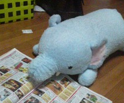

# webshotパッケージとは

- RでWebページのスクリーンショットを撮影
  - [PhantomJS](http://phantomjs.org/)というアプリケーションを利用
- 公式ドキュメントがわかりやすい
  - [GitHubサイト](https://github.com/wch/webshot/)
  - [CRAN上のvignette](https://cran.r-project.org/web/packages/webshot/vignettes/intro.html)
- どこで使うの?
  - 最近のR事情を考えるとわりと需要あり
  - 今回はvignetteを中心に紹介

# 準備

webshotのインストール:

```r
# CRANから
install.packages("webshot")
# GithHub版
devtools::install_github("wch/webshot")
```

- **使用するマシンにPhantomJSが使える必要あり**
  - [PhantomJS公式サイト](http://phantomjs.org/)からDL
  - インストールして`PATH`を通しておく
- 面倒だったら以下のコードを実行:

```r
webshot::install_phantomjs()
```

# hello, webshot

```r
library(webshot)
url <- "https://kazutan.github.io/kazutanR"
webshot(url, file = "pics/webshot_demo_01.png", delay = 0.5)
```

- まずは記念撮影
- webshot関数にurlを引き渡せばOK:

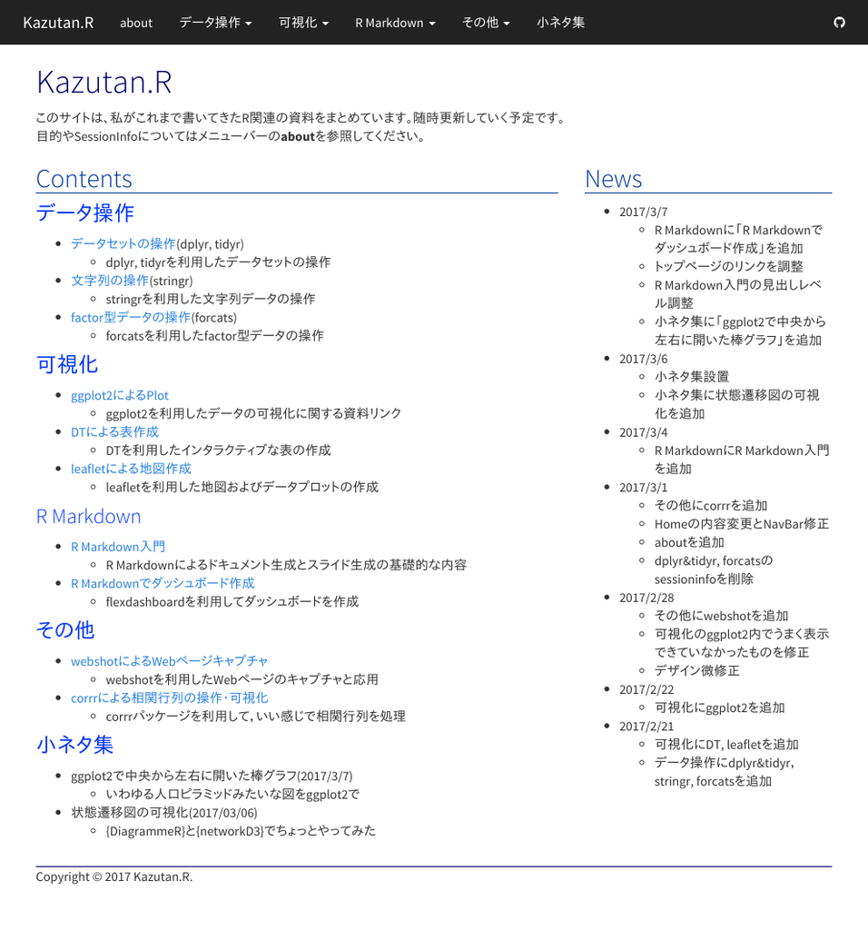

# `webshot()`関数について

### Usage:

```
webshot(url = NULL, file = "webshot.png", vwidth = 992, vheight = 744,
  cliprect = NULL, selector = NULL, expand = NULL, delay = 0.2,
  zoom = 1, eval = NULL)
```

### Arguments:

- 以前[Kazutan.R](https://kazutan.github.io/kazutanR/)にまとめたので，そちらを参照
- https://kazutan.github.io/kazutanR/webshot_demo.html

# webshotを使ってみる

### `cliprect`を利用

`cliprect = "viewport"`と指定すると，`vwidth`と`vheight`で指定したウィンドウサイズでスクリーンショットを撮影します:

[figure not shown]

```r
url2 <- "http://www.kyoritsu-pub.co.jp/bookdetail/9784320113169"
webshot(url2, file = "pics/webshot_demo_02.png",
        cliprect = "viewport",
        vwidth = 800,
        vheight = 600)
```

また，`cliprect`を具体的な値で指定も可能:

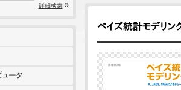

```r
webshot(url2, file = "pics/webshot_demo_03.png",
        cliprect = c(200, 100, 300, 150))
```

### `selector`を利用

セレクタを指定してみます:

[figure not shown]

```r
webshot(url2, file = "pics/webshot_demo_04.png",
        selector = "article#bookDetailMain")
```

# その他の関数について

- `resize()`関数
  - 画像をリサイズ
  - これを使用するためには**GraphicsMagick**もしくは**ImageMagick**が必要
  - 詳しくは関数のヘルプ`?resize`を参照
- `shrink()`関数
  - PNG画像のファイルサイズを縮小する関数
  - これを使用するためには**optipng**が必要
  - 詳しくは関数のヘルプ`?shrink`を参照

# 応用例

### htmlwidgetsオブジェクトの画像化

[figure not shown]

```r
library(dplyr)
library(leaflet)
library(htmlwidgets)

m <- leaflet() %>% addTiles() %>%
  addPopups(135, 35, "Popup!")

saveWidget(m, file = "leaflet2png.html")
webshot("leaflet2png.html",
        file = "pics/webshot_demo_05.png",
        delay = 2)
```

### R MarkdownでWebページキャプチャをhtmlドキュメントに埋め込む

*htmltools*を応用して*revealjs*用にサムネイル作成:

```r
library(htmltools)
thumbnail <- function(title, img, href, caption = TRUE) {
  tags$div(class = "column1",
      tags$a(class = "thumbnail", title = title, href = href,
        tags$img(src = img),
        tags$div(class = ifelse(caption, "caption", ""),
          ifelse(caption, title, "")
        )
      )
  )
}
```

```r
title <- c("原典", "日本語版")
urls <- c("https://sites.google.com/site/doingbayesiandataanalysis/",
          "http://www.kyoritsu-pub.co.jp/bookdetail/9784320113169")
imgs <- webshot(urls, file = "pics/thumb.png", cliprect = "viewport", delay = 1)

thumbs <- mapply(thumbnail, title = title, img = imgs, href = urls,
       SIMPLIFY = FALSE, USE.NAMES = FALSE)
tags$div(class = "row", thumbs)
```

実行するとこのような感じになります:

[figure not shown]

原典

[figure not shown]

日本語版

(cssは独自で調整済みです)

# さいごに

以下の情報を参照してください。

- [GitHubサイト](https://github.com/wch/webshot/)
  - READMEに基本的な使い方が書いてあります
- [CRAN上のvignette](https://cran.r-project.org/web/packages/webshot/vignettes/intro.html)
  - サンプルが豊富にあります
- [Webshotパッケージ - Kazutan.R](https://kazutan.github.io/kazutanR/webshot_demo.html)
  - 今回の内容をより詳しく説明しています

# Enjoy!

[figure not shown]

http://www.kyoritsu-pub.co.jp/bookdetail/9784320113169